# R Tutorial at the WZB

January 17, 2019

## Today's schedule

1. Review of last week's tasks
2. Record linkage: Combining data sets
3. Reproducible workflows with RStudio

## Review of last week's tasks

## Solution for tasks #8

now online on https://wzbsocialsciencecenter.github.io/wzb_r_tutorial/

## Record linkage

## What is record linkage?

*Record linkage* or *data joining* is the process of **combining observations** in a data set \(A\) with observations in a data set \(B\) according to some **matching criteria**. Most of the time, a matching criterion is a **common identifier**.

A

| id | x1 |
| --- | --- |
| 1 | 0.2875775 |
| 2 | 0.7883051 |
| 3 | 0.4089769 |
| 4 | 0.8830174 |
| 5 | 0.9404673 |

B

| id | x2 |
| --- | --- |
| 1 | 0 |
| 2 | 5 |
| 3 | 9 |
| 4 | 6 |
| 5 | 5 |

A and B

| id | x1 | x2 |
| --- | --- | --- |
| 1 | 0.2875775 | 0 |
| 2 | 0.7883051 | 5 |
| 3 | 0.4089769 | 9 |
| 4 | 0.8830174 | 6 |
| 5 | 0.9404673 | 5 |

\(A\) and \(B\) are joined by common identifier *"id"*.

If you have multiple data sets that can be combined, you have **relational data**.

## A practical example

Data from a repeated measures experiment:

```
##   person_id test_type score
## 1         1       pre     2
## 2         1      post     0
## 3         2       pre     3
## 4         2      post    10
## 5         3       pre     9
## 6         3      post     7
```

We also have "meta data" about each participant:

```
##   id age smoker
## 1  1  23   TRUE
## 2  3  42   TRUE
## 3  4  20  FALSE
```

We combine the data using a *left join* with criterion `person_id = id`:

```
##   person_id test_type score age smoker
## 1         1       pre     2  23   TRUE
## 2         1      post     0  23   TRUE
## 3         2       pre     3  NA     NA
## 4         2      post    10  NA     NA
## 5         3       pre     9  42   TRUE
## 6         3      post     7  42   TRUE
```

Notice how we introduced *NA*s, because participant ID 2 is missing in the "meta data". Also participant ID 4 does not appear in the result.

## Combining data sets with *dplyr*

There are several functions in the package *dplyr* (contained in *tidyverse*) for combining data sets:

- joins: `left_join`, `right_join`, `inner_join`, `full_join`, `semi_join`, `anti_join`
- set operations: `intersect`, `union`, `setdiff`
- row or column binding: `bind_rows`, `bind_cols`

We'll have a look at the most common operations.

## Data joining with *dplyr*

There are six join operations (of which three are commonly used).

All join operations have three parameters in common:

- a left hand side data set `a`
- a right hand side data set `b`
- a match criterion `by`

**The type of join operation determines which rows and values are retained.**

## Left and right joins

scores

| id | test_type | score |
| --- | --- | --- |
| 1 | pre | 10 |
| 1 | post | 5 |
| 2 | pre | 7 |
| 2 | post | 6 |
| 3 | pre | 1 |
| 3 | post | 9 |

personaldata

| id | age | smoker |
| --- | --- | --- |
| 1 | 23 | TRUE |
| 3 | 42 | TRUE |
| 4 | 20 | FALSE |

`left_join(a, b, by = <criterion>)`: **always retains rows on the "left side"** and fills up non-matching rows with *NA*s.

```r
left_join(scores, personaldata, by = c('id'))
```

```
##   id test_type score age smoker
## 1  1       pre    10  23   TRUE
## 2  1      post     5  23   TRUE
## 3  2       pre     7  NA     NA
## 4  2      post     6  NA     NA
## 5  3       pre     1  42   TRUE
## 6  3      post     9  42   TRUE
```

## Left and right joins

scores

| id | test_type | score |
| --- | --- | --- |
| 1 | pre | 10 |
| 1 | post | 5 |
| 2 | pre | 7 |
| 2 | post | 6 |
| 3 | pre | 1 |
| 3 | post | 9 |

personaldata

| id | age | smoker |
| --- | --- | --- |
| 1 | 23 | TRUE |
| 3 | 42 | TRUE |
| 4 | 20 | FALSE |

`right_join(a, b, by = <criterion>)`: **always retains rows on the "right side"** and fills up non-matching rows with *NA*s.

How many rows do you expect for a right join between `scores` and `personaldata`?

```r
right_join(scores, personaldata, by = c('id'))
```

```
##   id test_type score age smoker
## 1  1       pre    10  23   TRUE
## 2  1      post     5  23   TRUE
## 3  3       pre     1  42   TRUE
## 4  3      post     9  42   TRUE
## 5  4      <NA>    NA  20  FALSE
```

## Left and right joins

You can always transform a left join to a right join and vice versa.

Which of these statements are equivalent?

- `left_join(a, b, by = 'id')` and  
  `right_join(a, b, by = 'id')`
- `right_join(b, a, by = 'id')` and  
  `left_join(a, b, by = 'id')`
- `left_join(b, a, by = 'id')` and  
  `right_join(a, b, by = 'id')`

## Specifying match criteria

Match criteria are specified with parameter `by`.

experiments

| group | test_type | mean_score |
| --- | --- | --- |
| treat_A | pre | 6.405068 |
| treat_A | post | 9.942698 |
| treat_B | pre | 6.557058 |
| treat_B | post | 7.085305 |
| ctrl | pre | 5.440660 |
| ctrl | post | 5.941420 |

session_info

| group | test_type | n | lab |
| --- | --- | --- | --- |
| treat_A | pre | 11 | a |
| treat_A | post | 14 | b |
| treat_B | pre | 12 | b |
| treat_B | post | 10 | b |
| ctrl | pre | 13 | a |
| ctrl | post | 12 | a |

Parameter `by` is a character vector with all columns that must match:

```r
left_join(experiments, session_info, by = c('group', 'test_type'))
```

```
##     group test_type mean_score  n lab
## 1 treat_A       pre   6.405068 11   a
## 2 treat_A      post   9.942698 14   b
## 3 treat_B       pre   6.557058 12   b
## 4 treat_B      post   7.085305 10   b
## 5    ctrl       pre   5.440660 13   a
## 6    ctrl      post   5.941420 12   a
```

## Specifying match criteria

Parameter `by` can be a *named* character vector like `c('x' = 'y')`. This will match `a.x` to `b.y` (`x` of left-hand side to `y` of right-hand side).

This time, the `scores` data set has an ID column named `person_id`:

scores

| person_id | test_type | score |
| --- | --- | --- |
| 1 | pre | 2 |
| 1 | post | 0 |
| 2 | pre | 3 |
| 2 | post | 10 |
| 3 | pre | 9 |
| 3 | post | 7 |

personaldata

| id | age | smoker |
| --- | --- | --- |
| 1 | 23 | TRUE |
| 3 | 42 | TRUE |
| 4 | 20 | FALSE |

We have to consider that when specifying the matching criterion:

```r
left_join(scores, personaldata, by = c('person_id' = 'id'))
```

```
##   person_id test_type score age smoker
## 1         1       pre     2  23   TRUE
## 2         1      post     0  23   TRUE
## 3         2       pre     3  NA     NA
## 4         2      post    10  NA     NA
## 5         3       pre     9  42   TRUE
## 6         3      post     7  42   TRUE
```

## Inner join

scores

| person_id | test_type | score |
| --- | --- | --- |
| 1 | pre | 2 |
| 1 | post | 0 |
| 2 | pre | 3 |
| 2 | post | 10 |
| 3 | pre | 9 |
| 3 | post | 7 |

personaldata

| id | age | smoker |
| --- | --- | --- |
| 1 | 23 | TRUE |
| 3 | 42 | TRUE |
| 4 | 20 | FALSE |

`inner_join(a, b, by = <criterion>)`: **only retains rows that match on both sides.**

How many rows do you expect for an inner join between `scores` and `personaldata`?

```r
inner_join(scores, personaldata, by = c('person_id' = 'id'))
```

```
##   person_id test_type score age smoker
## 1         1       pre     2  23   TRUE
## 2         1      post     0  23   TRUE
## 3         3       pre     9  42   TRUE
## 4         3      post     7  42   TRUE
```

## Full join

scores

| person_id | test_type | score |
| --- | --- | --- |
| 1 | pre | 2 |
| 1 | post | 0 |
| 2 | pre | 3 |
| 2 | post | 10 |
| 3 | pre | 9 |
| 3 | post | 7 |

personaldata

| id | age | smoker |
| --- | --- | --- |
| 1 | 23 | TRUE |
| 3 | 42 | TRUE |
| 4 | 20 | FALSE |

`full_join(a, b, by = <criterion>)`: **retains all rows for both sides** and fills up non-matching rows with *NA*s.

How many rows do you expect for a full join between `scores` and `personaldata`?

```r
full_join(scores, personaldata, by = c('person_id' = 'id'))
```

```
##   person_id test_type score age smoker
## 1         1       pre     2  23   TRUE
## 2         1      post     0  23   TRUE
## 3         2       pre     3  NA     NA
## 4         2      post    10  NA     NA
## 5         3       pre     9  42   TRUE
## 6         3      post     7  42   TRUE
## 7         4      <NA>    NA  20  FALSE
```

## Semi join

scores

| person_id | test_type | score |
| --- | --- | --- |
| 1 | pre | 2 |
| 1 | post | 0 |
| 2 | pre | 3 |
| 2 | post | 10 |
| 3 | pre | 9 |
| 3 | post | 7 |

personaldata

| id | age | smoker |
| --- | --- | --- |
| 1 | 23 | TRUE |
| 3 | 42 | TRUE |
| 4 | 20 | FALSE |

`semi_join(a, b, by = <criterion>)`: A semi join is a *filtering join*. It returns **all observations of `a` where the criterion matches**.

```r
semi_join(scores, personaldata, by = c('person_id' = 'id'))
```

```
##   person_id test_type score
## 1         1       pre     2
## 2         1      post     0
## 3         3       pre     9
## 4         3      post     7
```

→ "return all scores for which we have personal data"

## Anti join

scores

| person_id | test_type | score |
| --- | --- | --- |
| 1 | pre | 2 |
| 1 | post | 0 |
| 2 | pre | 3 |
| 2 | post | 10 |
| 3 | pre | 9 |
| 3 | post | 7 |

personaldata

| id | age | smoker |
| --- | --- | --- |
| 1 | 23 | TRUE |
| 3 | 42 | TRUE |
| 4 | 20 | FALSE |

`anti_join(a, b, by = <criterion>)`: An anti join is the inverse of a semi join. It returns **all observations of `a` where the criterion does not match**.

```r
anti_join(scores, personaldata, by = c('person_id' = 'id'))
```

```
##   person_id test_type score
## 1         2       pre     3
## 2         2      post    10
```

→ "return all scores for which we have *no* personal data"

## Summary of data joins

An *inner join* matches keys that appear in both data sets and returns the combined observations:

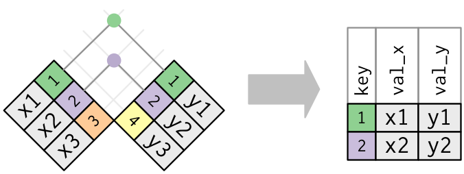

source: [Grolemund, Wickham 2017: R for Data Science](http://r4ds.had.co.nz/relational-data.html#inner-join)

## Summary of data joins

*Left and right outer joins* keep all observations on the left-hand or right-hand side data sets respectively. Unmatched rows are filled up with *NA*s:

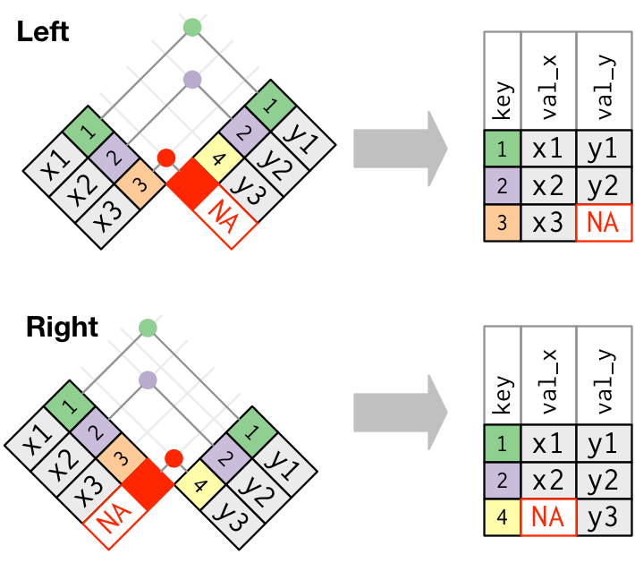

source: [Grolemund, Wickham 2017: R for Data Science](http://r4ds.had.co.nz/relational-data.html#inner-join)

## Summary of data joins

A *full outer join* keeps all observations of both data sets. Unmatched rows are filled up with *NA*s:

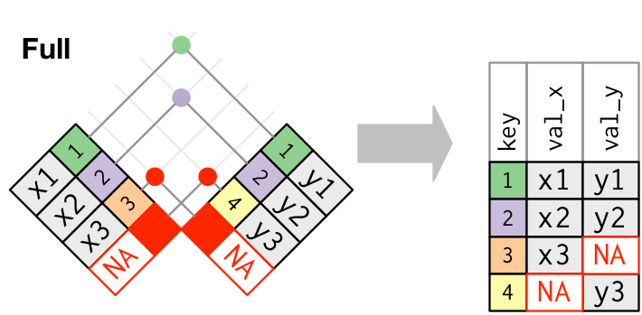

source: [Grolemund, Wickham 2017: R for Data Science](http://r4ds.had.co.nz/relational-data.html#inner-join)

## Set operations

Set operations as defined in the *dplyr* package operate on data frames. They translate to the same operations as you know from maths:

- `intersect(A, B)`: \(A \cap B\)  
  (observations that occur in both \(A\) and \(B\))
- `union(A, B)`: \(A \cup B\)  
  (observations that occur in either \(A\) or \(B\))
- `setdiff(A, B)`: \(A \setminus B\)  
  (observations that occur in \(A\) minus those that occur in \(B\))

There is no "match criterion". **All values** in a row are taken into account to match observations.

## Set operations

Some examples:

A

| x | y |
| --- | --- |
| 1 | 1 |
| 2 | 1 |
| 3 | 2 |

B

| x | y |
| --- | --- |
| 1 | 1 |
| 2 | 0 |
| 3 | 2 |

```r
intersect(A, B)
```

```
##   x y
## 1 1 1
## 2 3 2
```

```r
union(A, B)
```

```
##   x y
## 1 2 0
## 2 3 2
## 3 2 1
## 4 1 1
```

```r
setdiff(A, B)
```

```
##   x y
## 1 2 1
```

## Common mistakes

**1. Forgetting to specify `by`**

```r
left_join(scores, personaldata)
## Error: `by` required, because the data sources have no common variables
```

If there are common variables, they are used for matching by default, which is probably not what you want.

→ **always** specify `by`!

**2. Not using a (named) character vector for `by`**

```r
left_join(scores, personaldata, by = c(person_id = id))
## Error: `by` must specify variables to join by
```

→ quotes are missing (`c('person_id' = 'id')`)

```r
left_join(scores, personaldata, by = ('person_id' = 'id'))
## Error: `by` can't contain join column `id` which is missing from LHS
```

→ the little `c()` is missing to denote a vector

## Common mistakes

**3. Comparing the wrong types**

```r
A <- data.frame(id = 1:3, y = c(1, 1, 2))
B <- data.frame(id = as.factor(1:3), y = c(1, 0, 2))
inner_join(A, B, by = 'id')
## Error: Can't join on 'id' x 'id' because of incompatible types (integer / factor)
```

## Record linkage challenges

- Many things can go wrong (wrong join operation, wrong matching, etc.):  
  → check numbers of rows  
  → check for *NA*s  
  → check samples
- Which type of join should I use?  
  → think about which data *must* be retained and which data match can introduce *NA*s

## Record linkage challenges

- Often you need to combine more than two datasets:  
  → combine data sets one by one  
  → check at each step
- Sometimes there's no easy way of matching observations (no common identifiers):  
  → think of other strategies (other data sets, fuzzy matching, semi-automated matching)

## Reproducible workflows with RStudio

## Reproducible workflows

What is a reproducible workflow?

- allows **anybody** who meets your **software requirements** to reproduce your results **without programming trouble**
- **anybody** can also be your "future you"

Hence you need to provide:

- software requirements
- raw data*
- software / scripts that perform the data wrangling and analyses
- documentation

* subject to many limitations due to privacy and other considerations

## Why?

- makes sure your scripts run and are understandable when:
  - you change your computer
  - your "future you" comes back to the project after months or years
  - your collegues work with your code
  - another researcher tries to reproduce your results
- enforces transparency in the research process
- helps to find mistakes in your code
- helps in collaborative work

## How?

- **set up RStudio** correctly (next slide)
- use **RStudio projects** for anything that is not just "playing around"
- **never use `setwd()`** in your scripts
- write **clean code**:
  - structure your code with indentations
  - use meaningful object and variable names
- **document** your code

## Setting up RStudio

Go to *Tools > Global options…* → **Never** save workspace to file and never restore it on startup

[figure not shown]

## Setting up RStudio

Go to *Tools > Global options…* → **Never** save workspace to file and never restore it on startup

Why?

Because:

- your scripts **should run without workspace**
- you don't need a workspace – the important stuff is the scripts and the data
- you don't share a workspace – you share scripts and data
- "Restart R session" will not reload data: you can start afresh
- use "Restart R session" (`CTRL+SHIFT+F10`) **often** to check if scripts work when loaded afresh

## Working with RStudio projects

RStudio supports projects *(File > New project …)*. Use them!

Why?

Because:

- loading a project will set the working directory (no need to `setwd()`!) to the root of the project
- projects can be shared (RStudio creates a `myproject.Rproj` file)
- you can easily switch between projects (top right corner)

[figure not shown]

## Working with RMarkdown

You may have noticed that the solutions to the tasks involve a **mixture of code, plots and prose**. They're **RMarkdown documents**:

- allow to write text documents with sections ("chunks") of executable R code
- output can be saved as PDF, HTML, Word, etc.

My presentations are actually RMarkdown documents:

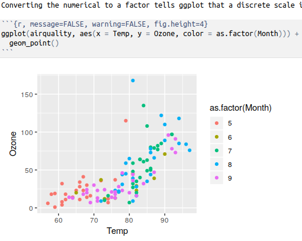

## Working with RMarkdown

Good for:

- **summaries** of your analyses / outcomes of a project
- exploratory data analysis
- small exercises

**Not** good for:

- complex, long running analyses
- complex programming code

→ use R scripts for that

## Working with RMarkdown

Create a new RMarkdown document (short: *Rmd*) in RStudio with *File > New file > RMarkdown …*.

→ creates a sample document with explanations and links to RMarkdown documentation

Make sure that Rmd documents are **reproducible**: Select *Run > Restart R and Run All Chunks*.

Free book: [R Markdown: The Definite Guide (Xie et al.)](https://bookdown.org/yihui/rmarkdown/)

## Concluding examples

Bad practice:

```r
setwd('C:/Research/Super Interesting Project/Analysis & more/')
X <- read.csv('cat_research_data.csv',stringsAsFactors =FALSE,
col.names= c('weight', 'age', 'length_tail'))
m <- mean(X$var2)
if (m> 8) {
print('fat cats!')
if(m > 12) {print('super fat cats!')}
}
S <- X[X$var2 > m,]
library(ggplot2)
qplot(S$var2, S$var3)
```

## Concluding examples

Better practice:

```r
# super important cat research script (no need for setwd() -- RStudio project!)
# author, date
library(ggplot2)  # put libraries on top

# load the data
catdata <- read.csv('cat_research_data.csv',
                    stringsAsFactors = FALSE,
                    col.names = c('weight', 'age', 'length_tail'))

# calculate mean weight and create subset with obs. where weight > mean weight
mean_weight <- mean(catdata$weight)
above_mean <- catdata[catdata$weight > mean_weight,]

if (mean_weight > 8) {  # just to show nested indentation
  print('fat cats!')
  if(mean_weight > 12) {
    print('super fat cats!')
  }
}

# scatter plot of above mean data with weight against length of cat's tail
qplot(above_mean$weight, above_mean$length_tail)
```

## Tasks

See dedicated tasks sheet on the [tutorial website](https://wzbsocialsciencecenter.github.io/wzb_r_tutorial/).